# Final Project: R Reference Guide

Megan Mitchell

12/16/2021

# R Reference Guide

## Loading Data and Packages

- Use these to show how to load the here and palmerpenguins packages - libary() and require()
- Ginkgo data: use the 2021 ginkgo data to create a data.frame called ginkgo using:

### Require()

#### Require() function allows loading a package that has already been installed in R.

### Library()

#### The Library() function is where all downloaded packages in R are stored.

```r
 # note, {.tabset .tabset-pills} can be used to make the R Markdown document with the individual blue tabs, also use "#" for the big header/main title, "##" for the tab header, and "###" for the headers nestled within the tabs. Also "*" makes bullet points.
require(here)
library(palmerpenguins)
```

### here()

#### The here() function allows the user to locate a file within a directory of the main RProject directory.

### read.csv()

#### The read.csv function allows csv files to be read by RStudio.

```r
ginkgo = data.frame(read.csv(here("data", "ginkgo_data_2021.csv")))
```

## Data Structures

### c()

#### The function c() combines or concatenates its arguments into a vector (a 1-dimensional data structure consisting of 1 or more elements).

- All of the elements must be of the same type.
- I can’t combine character and numeric types in the same call to c()
- Here’s two examples using numeric and character data types:

```r
## Create a vector of numbers:

num_vec  = c(1, 4, 8, 9, 13)

## Create a vector of characters:

char_vec = c("a", "fish", "data is cool")

## I can show the contents of a vector by typing the name of the vector, or using the print() function.

## Typing the name of the vector into the console prints the contents

num_vec
```

```
## [1]  1  4  8  9 13
```

```r
## [1]  1  4  8  9 13
```

### Print()

#### The print function prints the contents of a vector.

```r
print(char_vec)
```

```
## [1] "a"            "fish"         "data is cool"
```

```r
## [1] "a"            "fish"         "data is cool"
## The print() function accomplishes the same task:
```

### Length()

#### length() allows the user to get the length of the vector or other objectcs.

- For example, we can get the length of the vectors num_vec or char_vec

```r
length(num_vec)
```

```
## [1] 5
```

```r
length(char_vec)
```

```
## [1] 3
```

### Matrix()

#### A matrix is a collection of 2D data.

```r
matrix(num_vec)
```

```
##      [,1]
## [1,]    1
## [2,]    4
## [3,]    8
## [4,]    9
## [5,]   13
```

### dim()

#### dim returns the dimensions (rows + colu,ms) of the ginkgo data frame

```r
dim(ginkgo)
```

```
## [1] 756   6
```

### nrow()

- nrow tells us how many rows are in the data frame rather than the entire dimensions.

```r
nrow(ginkgo)
```

```
## [1] 756
```

### ncol()

- ncol tells us how many columns are in the data frame rather than the entire dimensions.

```r
ncol(ginkgo)
```

```
## [1] 6
```

## Subsetting

#### Subsetting is a useful function in R as it allows the user select, exclude, and filter object elements.

- Use the ginkgo data for these examples:

### $

- Subset a data frame by name: select one of the columns in the ginkgo data

```r
head(ginkgo$petiole_length)
```

```
## [1] 30 23 20 28 25 55
```

```r
tail(ginkgo$petiole_length)
```

```
## [1] 39 38 49 48 46 53
```

### []

- Use subset by position to: select first row of the ginkgo data,select the element in row 2, column 3, select the 3rd column of the ginkgo data

```r
head(ginkgo[1,]) # select first row of the ginkgo data
```

```
##   ï..site_id seeds_present max_width max_depth notch_depth petiole_length
## 1       7719         FALSE        71        40           0             30
```

```r
head(ginkgo[,3]) # select the third column
```

```
## [1] 71 64 55 62 65 70
```

```r
head(ginkgo[2,3]) # select the second row and third column
```

```
## [1] 64
```

### subset()

- Use this function to retrieve all the data for Adelie penguins (in the species column) from the peuguins dataset. Subsetting is very useful when your trying to select or filter certain objects within the data frame. In this case, we are interested in the Adelie penguins but not the Gentoo or Chinstrap species.

```r
subset(penguins, species == "Adelie")
```

```
## # A tibble: 152 x 8
##    species island    bill_length_mm bill_depth_mm flipper_length_mm body_mass_g
##    <fct>   <fct>              <dbl>         <dbl>             <int>       <int>
##  1 Adelie  Torgersen           39.1          18.7               181        3750
##  2 Adelie  Torgersen           39.5          17.4               186        3800
##  3 Adelie  Torgersen           40.3          18                 195        3250
##  4 Adelie  Torgersen           NA            NA                  NA          NA
##  5 Adelie  Torgersen           36.7          19.3               193        3450
##  6 Adelie  Torgersen           39.3          20.6               190        3650
##  7 Adelie  Torgersen           38.9          17.8               181        3625
##  8 Adelie  Torgersen           39.2          19.6               195        4675
##  9 Adelie  Torgersen           34.1          18.1               193        3475
## 10 Adelie  Torgersen           42            20.2               190        4250
## # ... with 142 more rows, and 2 more variables: sex <fct>, year <int>
```

```r
## dont forget the == sign when selecting what data you want to subset
```

## Numerical Data Exploration

### Summary

- this function provides a summary of the model or statistical analysis on the dataset.

```r
summary(penguins)
```

```
##       species          island    bill_length_mm  bill_depth_mm
##  Adelie   :152   Biscoe   :168   Min.   :32.10   Min.   :13.10
##  Chinstrap: 68   Dream    :124   1st Qu.:39.23   1st Qu.:15.60
##  Gentoo   :124   Torgersen: 52   Median :44.45   Median :17.30
##                                  Mean   :43.92   Mean   :17.15
##                                  3rd Qu.:48.50   3rd Qu.:18.70
##                                  Max.   :59.60   Max.   :21.50
##                                  NA's   :2       NA's   :2
##  flipper_length_mm  body_mass_g       sex           year
##  Min.   :172.0     Min.   :2700   female:165   Min.   :2007
##  1st Qu.:190.0     1st Qu.:3550   male  :168   1st Qu.:2007
##  Median :197.0     Median :4050   NA's  : 11   Median :2008
##  Mean   :200.9     Mean   :4202                Mean   :2008
##  3rd Qu.:213.0     3rd Qu.:4750                3rd Qu.:2009
##  Max.   :231.0     Max.   :6300                Max.   :2009
##  NA's   :2         NA's   :2
```

### Mean

- this function allows one to determine the average of the dataset. The mean can be calculated by summing the data and then dividing it by the number of things summed together.

```r
mean(penguins$bill_length_mm, na.rm = TRUE) # na.rm = TRUE is telling r to ignore any NA values. If we set na.rm = FALSE, then NA values are not removed.
```

```
## [1] 43.92193
```

### SD

- this function returns the standard deviation of the dataset, The sd gives us an idea of the distribution of data relative to the mean. Smaller sd means the population is more clustered around the mean whereas large sd suggest the population is dispersed farther from the mean.

```r
sd(penguins$bill_length_mm, na.rm = TRUE)
```

```
## [1] 5.459584
```

## Graphical Data Exploration

### Scatterplot()

- Using the ginkgo data, create a scatterplot of max leaf depth (x) and max leaf width (y).
- plot required arguments:

col = changes the color of the data points on the plot,

pch = changes the symbol of the data points. For example, pch = 2 generates triangles,

cex = this controls the scale (size) of the text and symbols. > 1 will be larger, <1 will be smaller, and 1 is the default size,

main = This function generates the title in the plot,

xlab = This function generates the labels on the x-axis ,

ylab = This function generates the labels on the y-axis,

xlim = This function controls the min and max values on the x-axis. This is helpful if you only want to emphasize certain areas on the plots to make visualizing data more clear.

ylim = This function controls the min and max on the y-axis. Again, this is helpful for visualizing data by only emphasizing the range you want to.

note, dev.off() erases plots in the environment. Also, rm(list = ls()) clears the environment.

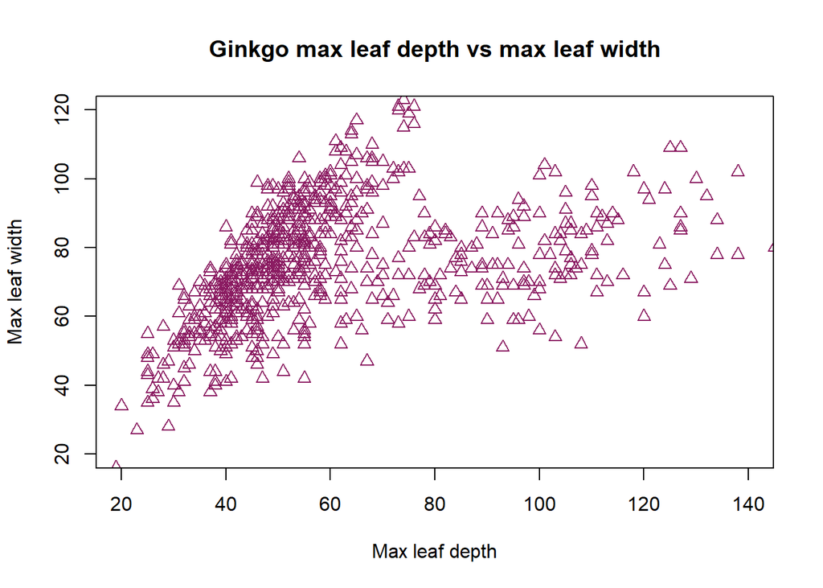

```r
plot(max_width ~ max_depth, data = ginkgo, main = "Ginkgo max leaf depth vs max leaf width",
     xlab = "Max leaf depth", ylab = "Max leaf width",
     pch = 2, cex = 1.1,
     col = "maroon4",
     xlim = c(20,140),
     ylim = c(20,120)
)
```

### hist()

- Create a histogram of penguin flipper lengths. Required arguments: breaks = controls the number of bars and bins on the histogram.

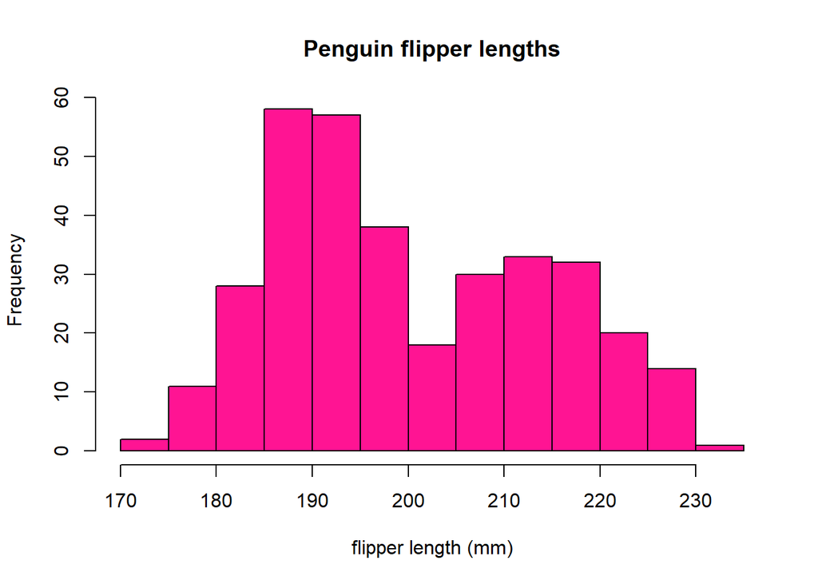

```r
hist(penguins$flipper_length_mm, breaks = 10, main = "Penguin flipper lengths", xlab = "flipper length (mm)", col = "deeppink")
```

### boxplot()

- Your must include two examples using the ginkgo data: a simple boxplot of ginkgo petiole lengths , conditional boxplot of one of the continuous variables conditioned on the seeds_present column.

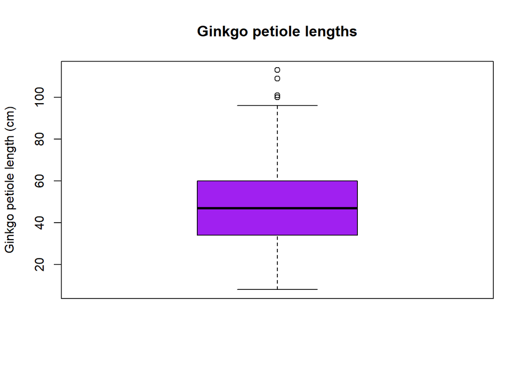

```r
boxplot(ginkgo$petiole_length, main = "Ginkgo petiole lengths",
        ylab = "Ginkgo petiole length (cm)", col = "purple") ## boxplot of ginkgo petiole length
```

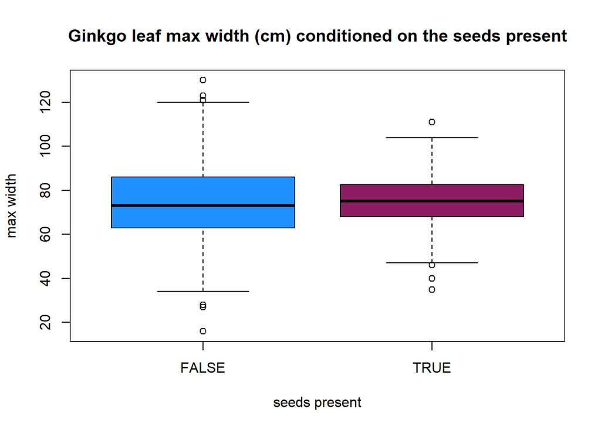

```r
boxplot(max_width ~ seeds_present, data = ginkgo,
        main = "Ginkgo leaf max width (cm) conditioned on the seeds present",
        ylab = "max width", xlab = "seeds present",
        col = c("dodgerblue", "maroon4"))   ## note, you can also color the plots using "col = rainbow(ncol(ginkgo)))
```

```r
# boxplot of max width conditioned by whether seeds were /werenot present. Note, the tilda sign "~" allows conditioning the seeds present on a continuous variable .
```

### 4-panel figure of histograms

- arranged in a 2 by 2 grid. You may use any data you like, but each histogram must be different and have appropriate titles and axes. - par() required arguments: - mrow = # ### this code allows for arranging plots in a panel –> par(mfrow = c(#row, #column)) . If we wanted 1 column and 3 rows, it would be par(mfrow = c (3,1))

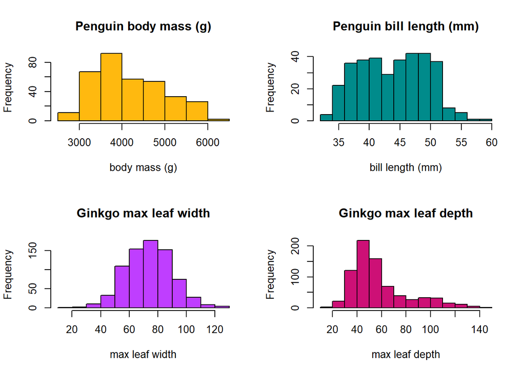

```r
par(mfrow = c(2, 2))
hist(penguins$body_mass_g, main= "Penguin body mass (g)", xlab = "body mass (g)", col = "darkgoldenrod1")
hist(penguins$bill_length_mm, main="Penguin bill length (mm)", xlab="bill length (mm)", col = "cyan4")
hist(ginkgo$max_width, main = "Ginkgo max leaf width", xlab = "max leaf width", col = "darkorchid1")
hist(ginkgo$max_depth, main = "Ginkgo max leaf depth", xlab = "max leaf depth", col = "deeppink3")
```

## Distribution Functions

### Normal distribution

#### Normal distribution is when data tends to more closely lie around the mean rather than dispersed away from the mean. Visually, this would show a bell-shaped histogram with the majority of the population at the center. As sample size increases, data becomes more normally distributed.

### dnorm()

*The Probability Density Function –> dnorm(x, mean = 0, sd = 1, log = FALSE)

```r
dnorm(x=6, mean = 2, sd = 0.7, log = FALSE)  # note x = vector of quantiles. This function is telling R to compute the probability of observing a value of 6 in a normally distributed population with a mean of 2 and a sd of 0.7
```

```
## [1] 4.626897e-08
```

### pnorm()

- Cumulative density function –> pnorm(q, mean = 0, sd = 1, lower.tail = TRUE, log.p = FALSE)

```r
pnorm(q=6, mean = 2, sd = 0.7, lower.tail = TRUE, log.p = FALSE) # note q= vector of quantiles. This function is telling R to compute the probability of observing a value of 6 or LOWER in a normally distributed population with a mean of 2 and sd of 0.7
```

```
## [1] 1
```

### qnorm()

- Quantile function for the normal distribution. –> qnorm(p, mean = 0, sd = 1, lower.tail = TRUE, log.p = FALSE)

```r
qnorm(p = 0.5, mean = 2, sd = 0.7) # note p = vector of probabilities. This function is telling R to compute the median value for a normally distributed population with a mean of 2 and sd of 0.7
```

```
## [1] 2
```

### rnorm()

- Random generation (generates random deviates) –> rnorm(n, mean = 0, sd = 1)

```r
rnorm(6, 2, 0.7)
```

```
## [1] 1.393994 2.571348 2.409352 2.883808 3.183983 1.786645
```

### Binomial Distribution

#### Binomial distribution is when data has discrete probability distributions so there can only be two outcomes such as success/failure or yes/no. There are only two parameters in binomial distribution, which are n and p. An example of this would be flipping a coin.

### dbinom()

- Probability Density Function for the binomial distribution –> dbinom(x, size, prob, log = FALSE)

```r
dbinom(2, 10, 0.5) # This function is asking R to compute the probability of observing a value of 2 in a binomial distributed population with n=10 and a probability of 0.5.
```

```
## [1] 0.04394531
```

### pbinom()

- Cumulative mass function for the binomial distribution –> pbinom(q, size, prob, lower.tail = TRUE, log.p = FALSE)

```r
pbinom(2, 10, 0.5) # This function is asking R to compute the probability of observing a value of 2 or LESS in a binomial distributed population with n=10 and a probability of 0.5
```

```
## [1] 0.0546875
```

### qbinom()

- Quantile function for the binomial distribution –> qbinom(p, size, prob, lower.tail = TRUE, log.p = FALSE)

```r
qbinom(0.5,10,0.5) # This function is asking R to compute the median for a population with n=10 and a probability of 0.5
```

```
## [1] 5
```

### rbinom

- Random generation for the binomail distribution

```r
rbinom(2,10,0.5)
```

```
## [1] 7 4
```